# Time series forcasting for Corona19 cases in India

## Forcasting using Facebooks’ Prophet model on Indian [Corona-19](https://www.covid19india.org/) dataset: an approach for performance evaluation

by Ashish

[figure not shown]

[Photograph taken by Jatinder Singh, near Murdeshwar, Karnataka 581350 on 21 oct 2018](https://maps.app.goo.gl/jfQicggB355RtoDZ7)

### Content

Introduction:

Model overview, data exploration and some teaser for next sections

Analysis

Data exploration and establishment of some assumption

Prophecy

Performance metrics

Conclusion

## Introduction

*Time series forcasing* is an application of supervised training. A model is build to predict values from date with past data as training data by feeding the model with future dates, it produces forcasted values for the future dates.

Model is build by finding a best smooth line which can be represented as sum of the components like overall growth trends, yearly seasonality, weekly seasonality, Holiday effects.

[Prophet time series](https://doi.org/10.7287/peerj.preprints.3190v2) = Trend + Seasonality + Holiday + error

`Trend models` non periodic changes in the value of the time series.

`Seasonality` is the periodic changes like daily, weekly, or yearly seasonality.

`Holiday effect` which occur on irregular schedules over a day or a period of days.

`Error terms` is what is not explained by the model.

The [advantage](https://facebook.github.io/prophet/) of the this model over other Time series model (like ARIMA,SARIMA etc.) are

- Work best on the strong seasonal effect data as it support yearly, weekly, and daily seasonality, plus holiday effects
- It handels outliers as well
- It is robost in handeling missing values

*Requirements*

This project is done using python **fbprophet** library using Anaconda. For fbprophet library install following command is used [conda install -c conda-forge fbprophet](https://anaconda.org/conda-forge/fbprophet) in administrator mode on Anaconda Navigator. This can also be installed using [pip install fbprophet](https://pypi.org/project/fbprophet/). Other dependencies are

- numpy
- pandas
- requests
- seaborn
- datetime
- matplotlib
- time

To delete all the variables in workspace we use python magic function and to ignore all the warning while running commands in cell warnings are used.

```python
%reset -f
import warnings
warnings.filterwarnings("ignore")# To ignore the warnings
```

```python
import numpy as np
import pandas as pd
import requests
import seaborn as sns
from time import strptime
import re
import datetime
import matplotlib.pyplot as plt
plt.style.use('seaborn-white')
sns.set(style="ticks")
plt.figure(figsize=(10, 6))
import fbprophet
from fbprophet.plot import add_changepoints_to_plot
%matplotlib inline
data_url = "https://api.covid19india.org/data.json"
data=requests.get(data_url).json()
delta=pd.DataFrame(data.get('key_values'))
cases_time_series=pd.DataFrame(data.get('cases_time_series'))
```

```python
print(cases_time_series.dtypes)
cases_time_series.head(2)
```

```
dailyconfirmed    object
dailydeceased     object
dailyrecovered    object
date              object
totalconfirmed    object
totaldeceased     object
totalrecovered    object
dtype: object
```

|  | dailyconfirmed | dailydeceased | dailyrecovered | date | totalconfirmed | totaldeceased | totalrecovered |
| --- | --- | --- | --- | --- | --- | --- | --- |
| 0 | 1 | 0 | 0 | 30 January | 1 | 0 | 0 |
| 1 | 0 | 0 | 0 | 31 January | 1 | 0 | 0 |

If you observe the above cell, then you can see all the columns are having object datatype, which need to be converted to integer ( to dailyconfirmed, dailydeceased, dailyrecovered, totalconfirmed, totaldeceased, totalrecovered) and datetime (to date), it is done in the below cells.

```python
cases_time_series[["dailyconfirmed","dailydeceased","dailyrecovered","totalconfirmed","totaldeceased","totalrecovered"]]=cases_time_series[["dailyconfirmed","dailydeceased","dailyrecovered","totalconfirmed","totaldeceased","totalrecovered"]].astype(int)
```

```python
start = datetime.datetime(2020,strptime("".join(re.findall(r'[^\d]',cases_time_series.date.iloc[0])).strip()[:3],'%b').tm_mon,int(re.findall(r'\d+',cases_time_series.date.iloc[0])[0]))
end = datetime.datetime(2020,strptime("".join(re.findall(r'[^\d]',cases_time_series.date.iloc[-1])).strip()[:3],'%b').tm_mon,int(re.findall(r'\d+',cases_time_series.date.iloc[-1])[0]))
delta = end - start
cases_time_series.date=pd.DataFrame([start + datetime.timedelta(days=i) for i in range(delta.days + 1)])
cases_time_series.head(2)
```

|  | dailyconfirmed | dailydeceased | dailyrecovered | date | totalconfirmed | totaldeceased | totalrecovered |
| --- | --- | --- | --- | --- | --- | --- | --- |
| 0 | 1 | 0 | 0 | 2020-01-30 | 1 | 0 | 0 |
| 1 | 0 | 0 | 0 | 2020-01-31 | 1 | 0 | 0 |

head function is use to show the dataframe from top. By default it shows 5 rows but we can custimize it as shown in above cell. The .tail() function is used to show the element from below.

```python
cases_time_series.tail(2)
```

|  | dailyconfirmed | dailydeceased | dailyrecovered | date | totalconfirmed | totaldeceased | totalrecovered |
| --- | --- | --- | --- | --- | --- | --- | --- |
| 97 | 3602 | 91 | 1161 | 2020-05-06 | 53007 | 1785 | 15301 |
| 98 | 3344 | 104 | 1475 | 2020-05-07 | 56351 | 1889 | 16776 |

```python
cases_time_series.info()
```

```
<class 'pandas.core.frame.DataFrame'>
RangeIndex: 99 entries, 0 to 98
Data columns (total 7 columns):
dailyconfirmed    99 non-null int32
dailydeceased     99 non-null int32
dailyrecovered    99 non-null int32
date              99 non-null datetime64[ns]
totalconfirmed    99 non-null int32
totaldeceased     99 non-null int32
totalrecovered    99 non-null int32
dtypes: datetime64[ns](1), int32(6)
memory usage: 3.2 KB
```

As no missing values are there our data so, we don't need to do further data processing.

## Analysis

```python
cases_time_series.describe()
```

|  | dailyconfirmed | dailydeceased | dailyrecovered | totalconfirmed | totaldeceased | totalrecovered |
| --- | --- | --- | --- | --- | --- | --- |
| count | 99.000000 | 99.000000 | 99.000000 | 99.000000 | 99.000000 | 99.000000 |
| mean | 569.202020 | 19.080808 | 169.454545 | 7931.686869 | 259.464646 | 1806.868687 |
| std | 896.852683 | 31.083061 | 323.187798 | 13870.688015 | 462.374138 | 3762.529877 |
| min | 0.000000 | 0.000000 | 0.000000 | 1.000000 | 0.000000 | 0.000000 |
| 25% | 0.000000 | 0.000000 | 0.000000 | 3.000000 | 0.000000 | 3.000000 |
| 50% | 27.000000 | 1.000000 | 2.000000 | 198.000000 | 4.000000 | 20.000000 |
| 75% | 878.500000 | 30.000000 | 147.500000 | 9832.500000 | 345.500000 | 1142.000000 |
| max | 3656.000000 | 140.000000 | 1475.000000 | 56351.000000 | 1889.000000 | 16776.000000 |

```python
cases_time_series["WeekDays"]=cases_time_series["date"].dt.day_name()
```

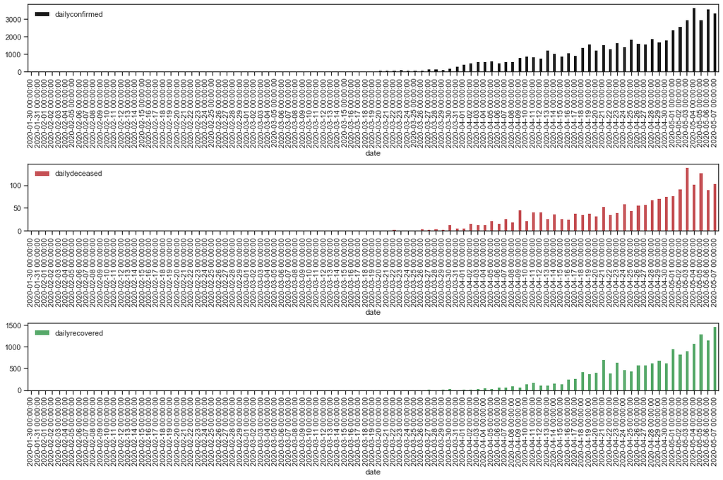

```python
fig, axs = plt.subplots(3,1,figsize=(15,10))
cases_time_series.plot(x='date', y='dailyconfirmed',kind = 'bar',color='k',ax=axs[0])
cases_time_series.plot(x='date', y='dailydeceased',kind = 'bar',color='r',ax=axs[1])
cases_time_series.plot(x='date', y='dailyrecovered',kind = 'bar',color='g',ax=axs[2])
plt.tight_layout()
```

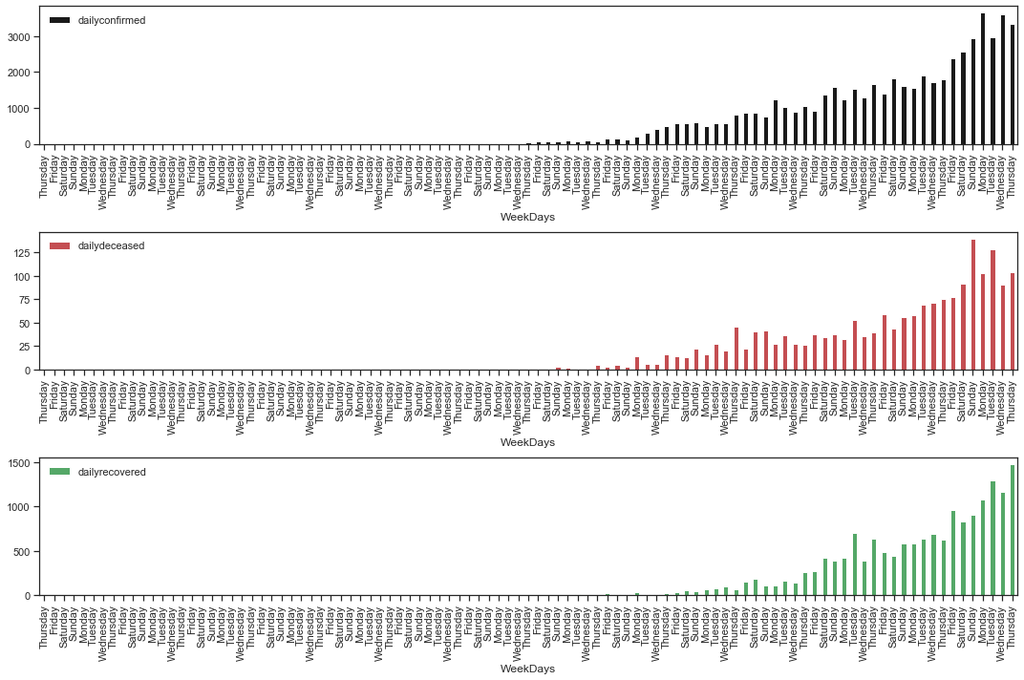

```python
fig, axs = plt.subplots(3,1,figsize=(15,10))
cases_time_series.plot(x='WeekDays', y='dailyconfirmed',kind = 'bar',color='k',ax=axs[0])
cases_time_series.plot(x='WeekDays', y='dailydeceased',kind = 'bar',color='r',ax=axs[1])
cases_time_series.plot(x='WeekDays', y='dailyrecovered',kind = 'bar',color='g',ax=axs[2])
plt.tight_layout()
```

From the above graph any pattern is observed. So, holidays on weekends effect is not taken into account. For [modeling holidays and special events](https://facebook.github.io/prophet/docs/seasonality,_holiday_effects,_and_regressors.html) which we can include as condition in Prophet model.

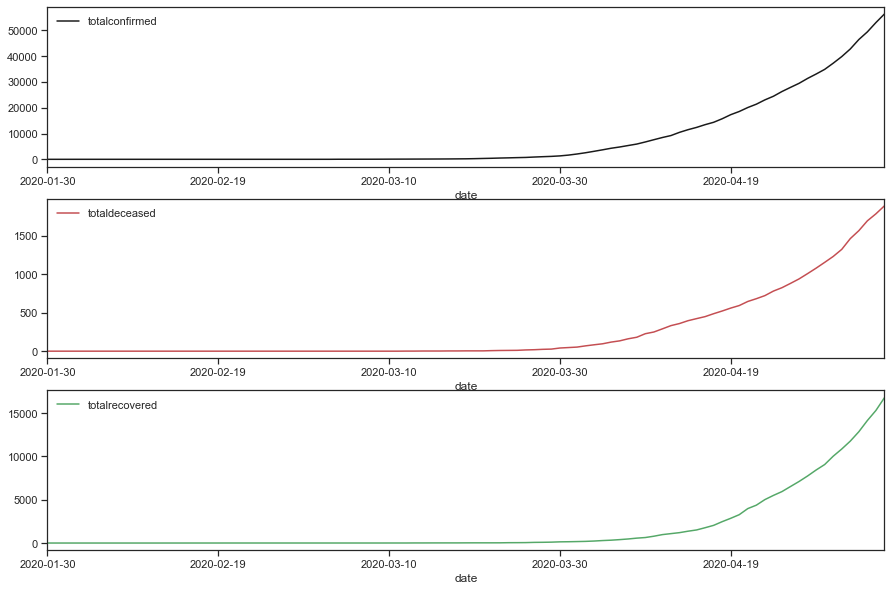

```python
fig, axs = plt.subplots(3,1,figsize=(15,10))
cases_time_series.date=cases_time_series.date.astype(str)
cases_time_series.plot(x='date', y='totalconfirmed',color='k',ax=axs[0])
cases_time_series.plot(x='date', y='totaldeceased',color='r',ax=axs[1])
cases_time_series.plot(x='date', y='totalrecovered',color='g',ax=axs[2])
```

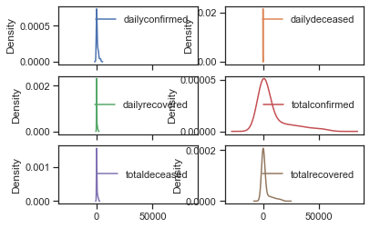

```python
cases_time_series[["dailyconfirmed","dailydeceased","dailyrecovered","totalconfirmed","totaldeceased","totalrecovered"]].plot(kind='density', subplots=True, layout=(3,2), sharex=True)
plt.show()
plt.tight_layout()
```

```python
cases_time_series[["dailyconfirmed","dailydeceased","dailyrecovered","totalconfirmed","totaldeceased","totalrecovered"]].corr(method ='pearson').style.background_gradient(cmap='coolwarm')
```

|  | dailyconfirmed | dailydeceased | dailyrecovered | totalconfirmed | totaldeceased | totalrecovered |
| --- | --- | --- | --- | --- | --- | --- |
| dailyconfirmed | 1 | 0.96223 | 0.963851 | 0.98121 | 0.981206 | 0.952695 |
| dailydeceased | 0.96223 | 1 | 0.94158 | 0.962603 | 0.965167 | 0.938077 |
| dailyrecovered | 0.963851 | 0.94158 | 1 | 0.984117 | 0.984635 | 0.981339 |
| totalconfirmed | 0.98121 | 0.962603 | 0.984117 | 1 | 0.999472 | 0.985191 |
| totaldeceased | 0.981206 | 0.965167 | 0.984635 | 0.999472 | 1 | 0.986853 |
| totalrecovered | 0.952695 | 0.938077 | 0.981339 | 0.985191 | 0.986853 | 1 |

## Prophecy

```python
forcast=7#int(input("Number of days that you want to forcast:"))
```

```python
#### Forecaster model
def forecast(df,ds,y,y_label='y',title="Projection", plot=False):
    df = df[[ds, y]]
    df=df.rename(columns={ds: 'ds', y: 'y'})
    prophet = fbprophet.Prophet(changepoint_range=0.9,changepoint_prior_scale=0.2,weekly_seasonality=False,daily_seasonality=True,yearly_seasonality=False)
    prophet.fit(df)
    forecast = prophet.make_future_dataframe(periods=forcast, freq='D')# make_future_dataframe() to which we specify the number of days to extend into the future.
    forecast = prophet.predict(forecast)
    # Avoid negative
    forecast["yhat"] = np.where(forecast["yhat"]<0,0,forecast["yhat"])
    forecast["yhat_lower"] = np.where(forecast["yhat_lower"]<0,0,forecast["yhat_lower"])
    forecast["yhat_upper"] = np.where(forecast["yhat_upper"]<0,0,forecast["yhat_upper"])
    if plot :
        fig=prophet.plot(forecast, xlabel = 'Date', ylabel = y_label)
        a = add_changepoints_to_plot(fig.gca(), prophet, forecast)
        plt.title(title);
    return (forecast,df)
```

```
INFO:numexpr.utils:NumExpr defaulting to 8 threads.
```

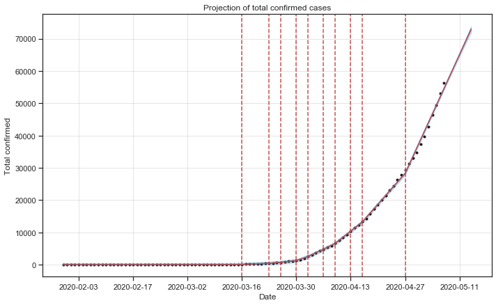

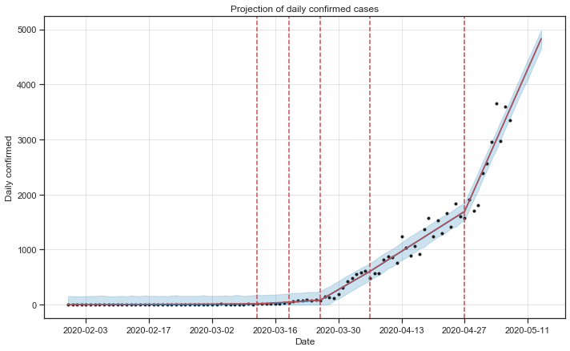

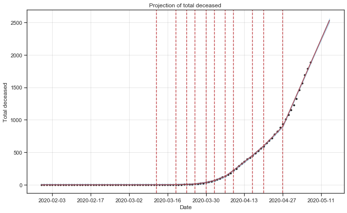

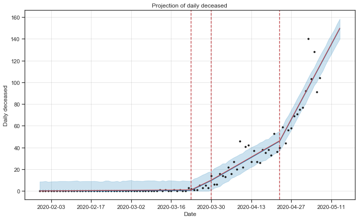

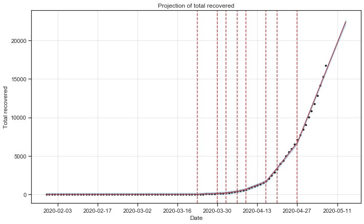

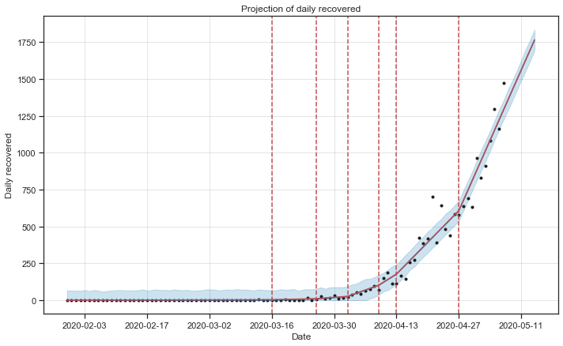

```python
f1=forecast(cases_time_series,"date", "totalconfirmed",y_label="Total confirmed",title="Projection of total confirmed cases", plot=True)
f2=forecast(cases_time_series,"date", "dailyconfirmed",y_label="Daily confirmed",title="Projection of daily confirmed cases", plot=True)
f3=forecast(cases_time_series,"date", "totaldeceased",y_label="Total deceased",title="Projection of total deceased", plot=True)
f4=forecast(cases_time_series,"date", "dailydeceased",y_label="Daily deceased",title="Projection of daily deceased", plot=True)
f5 =forecast(cases_time_series,"date", "totalrecovered",y_label="Total recovered",title="Projection of total recovered", plot=True)
f6=forecast(cases_time_series,"date", "dailyrecovered",y_label="Daily recovered",title="Projection of daily recovered", plot=True)
```

[output not shown]

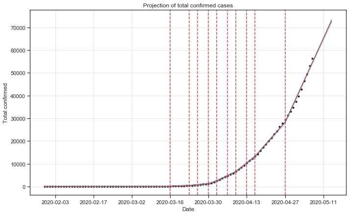

```python
f1=forecast(cases_time_series,"date", "totalconfirmed",y_label="Total confirmed",title="Projection of total confirmed cases", plot=True)
pd.concat([f1[1],f1[0][["yhat","yhat_lower","yhat_upper"]].iloc[:len(f1[1]),:]],axis=1).tail(2)
```

[output not shown]

```python
f1[0][["ds","yhat","yhat_lower","yhat_upper"]].tail(8)
```

|  | ds | yhat | yhat_lower | yhat_upper |
| --- | --- | --- | --- | --- |
| 98 | 2020-05-07 | 54542.651411 | 54001.425756 | 55057.236576 |
| 99 | 2020-05-08 | 57169.981104 | 56634.611946 | 57673.743702 |
| 100 | 2020-05-09 | 59797.310798 | 59226.823883 | 60290.289762 |
| 101 | 2020-05-10 | 62424.640491 | 61836.209985 | 62975.771982 |
| 102 | 2020-05-11 | 65051.970185 | 64429.358397 | 65679.358722 |
| 103 | 2020-05-12 | 67679.299879 | 67004.737885 | 68398.371469 |
| 104 | 2020-05-13 | 70306.629572 | 69471.190073 | 71140.249518 |
| 105 | 2020-05-14 | 72933.959266 | 71952.773150 | 73912.707550 |

```python
aa=f1[0][["ds","yhat","yhat_lower","yhat_upper"]].tail(8)
aa.columns=[["Date","Simulated result","Lower uncertainty band value","Upper uncertainty band value"]]
```

```python
aa
```

|  | Date | Simulated result | Lower uncertainty band value | Upper uncertainty band value |
| --- | --- | --- | --- | --- |
| 98 | 2020-05-07 | 54542.651411 | 54001.425756 | 55057.236576 |
| 99 | 2020-05-08 | 57169.981104 | 56634.611946 | 57673.743702 |
| 100 | 2020-05-09 | 59797.310798 | 59226.823883 | 60290.289762 |
| 101 | 2020-05-10 | 62424.640491 | 61836.209985 | 62975.771982 |
| 102 | 2020-05-11 | 65051.970185 | 64429.358397 | 65679.358722 |
| 103 | 2020-05-12 | 67679.299879 | 67004.737885 | 68398.371469 |
| 104 | 2020-05-13 | 70306.629572 | 69471.190073 | 71140.249518 |
| 105 | 2020-05-14 | 72933.959266 | 71952.773150 | 73912.707550 |

```python
aa.iloc[:,1:]=aa.iloc[:,1:].astype(int)
```

```python
aa
```

|  | Date | Simulated result | Lower uncertainty band value | Upper uncertainty band value |
| --- | --- | --- | --- | --- |
| 98 | 2020-05-07 | 54542 | 54001 | 55057 |
| 99 | 2020-05-08 | 57169 | 56634 | 57673 |
| 100 | 2020-05-09 | 59797 | 59226 | 60290 |
| 101 | 2020-05-10 | 62424 | 61836 | 62975 |
| 102 | 2020-05-11 | 65051 | 64429 | 65679 |
| 103 | 2020-05-12 | 67679 | 67004 | 68398 |
| 104 | 2020-05-13 | 70306 | 69471 | 71140 |
| 105 | 2020-05-14 | 72933 | 71952 | 73912 |

## Performance metrics

```python
# Nash-Sutcliffe Efficiency
def nse(simulation_s, evaluation):
    nse_ = 1 - (np.sum((evaluation - simulation_s) ** 2, axis=0, dtype=np.float64) /
                np.sum((evaluation - np.mean(evaluation)) ** 2, dtype=np.float64))
    return nse_
# Root Mean Square Error
def rmse(simulation_s, evaluation):
    rmse_ = np.sqrt(np.mean((evaluation - simulation_s) ** 2, axis=0, dtype=np.float64))
    return rmse_
```

```python
print("Nash-Sutcliffe efficiency for Total confirmed cases is ",nse(np.array(f1[1][["y"]]),np.array(f1[0][["yhat"]].iloc[:len(f1[1]),:]))[0])
print("Root Mean Square Error for Total confirmed cases is ",rmse(np.array(f1[1][["y"]]),np.array(f1[0][["yhat"]].iloc[:len(f1[1]),:]))[0])
print("Coefficient of determination for Total confirmed cases")
pd.concat([f1[1],f1[0][["yhat"]].iloc[:len(f1[1]),:]],axis=1).corr(method ='pearson').style.background_gradient(cmap='coolwarm')
```

```
Nash-Sutcliffe efficiency for Total confirmed cases is  0.9991298397971556
Root Mean Square Error for Total confirmed cases is  406.8285622981411
Coefficient of determination for Total confirmed cases
```

|  | y | yhat |
| --- | --- | --- |
| y | 1 | 0.999565 |
| yhat | 0.999565 | 1 |

```python
print("Nash-Sutcliffe efficiency for Daily confirmed cases is ",nse(np.array(f2[1][["y"]]),np.array(f2[0][["yhat"]].iloc[:len(f2[1]),:]))[0])
print("Root Mean Square Error for Daily confirmed cases is ",rmse(np.array(f2[1][["y"]]),np.array(f2[0][["yhat"]].iloc[:len(f2[1]),:]))[0])
print("Coefficient of determination for Daily confirmed cases")
pd.concat([f2[1],f2[0][["yhat"]].iloc[:len(f2[1]),:]],axis=1).corr(method ='pearson').style.background_gradient(cmap='coolwarm')
```

```
Nash-Sutcliffe efficiency for Daily confirmed cases is  0.9799259685067954
Root Mean Square Error for Daily confirmed cases is  124.50167205161006
Coefficient of determination for Daily confirmed cases
```

|  | y | yhat |
| --- | --- | --- |
| y | 1 | 0.990234 |
| yhat | 0.990234 | 1 |

```python
print("Nash-Sutcliffe efficiency for Total deceased cases is ",nse(np.array(f3[1][["y"]]),np.array(f3[0][["yhat"]].iloc[:len(f3[1]),:]))[0])
print("Root Mean Square Error for Total deceased cases is ",rmse(np.array(f3[1][["y"]]),np.array(f3[0][["yhat"]].iloc[:len(f3[1]),:]))[0])
print("Coefficient of determination for Total deceased cases")
pd.concat([f3[1],f3[0][["yhat"]].iloc[:len(f3[1]),:]],axis=1).corr(method ='pearson').style.background_gradient(cmap='coolwarm')
```

```
Nash-Sutcliffe efficiency for Total deceased cases is  0.9993972845988839
Root Mean Square Error for Total deceased cases is  11.288624056174895
Coefficient of determination for Total deceased cases
```

|  | y | yhat |
| --- | --- | --- |
| y | 1 | 0.999699 |
| yhat | 0.999699 | 1 |

```python
print("Nash-Sutcliffe efficiency for Daily deceased cases is ",nse(np.array(f4[1][["y"]]),np.array(f4[0][["yhat"]].iloc[:len(f4[1]),:]))[0])
print("Root Mean Square Error for Daily deceased cases is ",rmse(np.array(f4[1][["y"]]),np.array(f4[0][["yhat"]].iloc[:len(f4[1]),:]))[0])
print("Coefficient of determination for Daily deceased cases")
pd.concat([f4[1],f4[0][["yhat"]].iloc[:len(f4[1]),:]],axis=1).corr(method ='pearson').style.background_gradient(cmap='coolwarm')
```

```
Nash-Sutcliffe efficiency for Daily deceased cases is  0.9437947787415255
Root Mean Square Error for Daily deceased cases is  7.0630030880278785
Coefficient of determination for Daily deceased cases
```

|  | y | yhat |
| --- | --- | --- |
| y | 1 | 0.973626 |
| yhat | 0.973626 | 1 |

```python
print("Nash-Sutcliffe efficiency for Total recovered cases is ",nse(np.array(f5[1][["y"]]),np.array(f5[0][["yhat"]].iloc[:len(f5[1]),:]))[0])
print("Root Mean Square Error for Total recovered cases is ",rmse(np.array(f5[1][["y"]]),np.array(f5[0][["yhat"]].iloc[:len(f5[1]),:]))[0])
print("Coefficient of determination for Total recovered cases")
pd.concat([f5[1],f5[0][["yhat"]].iloc[:len(f5[1]),:]],axis=1).corr(method ='pearson').style.background_gradient(cmap='coolwarm')
```

```
Nash-Sutcliffe efficiency for Total recovered cases is  0.9984856301513558
Root Mean Square Error for Total recovered cases is  145.50350809587118
Coefficient of determination for Total recovered cases
```

|  | y | yhat |
| --- | --- | --- |
| y | 1 | 0.999244 |
| yhat | 0.999244 | 1 |

```python
print("Nash-Sutcliffe efficiency for Daily recovered cases is ",nse(np.array(f6[1][["y"]]),np.array(f6[0][["yhat"]].iloc[:len(f6[1]),:]))[0])
print("Root Mean Square Error for Daily recovered cases is ",rmse(np.array(f6[1][["y"]]),np.array(f6[0][["yhat"]].iloc[:len(f6[1]),:]))[0])
print("Coefficient of determination for Daily recovered cases")
pd.concat([f6[1],f6[0][["yhat"]].iloc[:len(f6[1]),:]],axis=1).corr(method ='pearson').style.background_gradient(cmap='coolwarm')
```

```
Nash-Sutcliffe efficiency for Daily recovered cases is  0.9714308739572526
Root Mean Square Error for Daily recovered cases is  53.23236829334624
Coefficient of determination for Daily recovered cases
```

|  | y | yhat |
| --- | --- | --- |
| y | 1 | 0.986225 |
| yhat | 0.986225 | 1 |

## Reference

- [Covid19](https://www.covid19india.org/)
- [Prophet Document](https://facebook.github.io/prophet/docs/installation.html)
- [Time series prediction using Prophet in Python](https://towardsdatascience.com/time-series-prediction-using-prophet-in-python-35d65f626236)